# Reproducible Research: Peer Assessment 1

# Introduction

This is peer graded assignment 1 of Reproducible research. In this assignment, students were asked to perform basic R programming and obtain results whilst presenting them in a orderly fashion through usage of R markdown.

## Data

The activity data provided in the assignment has been gathered from a personal activity monitoring device.

# Assignment

### Loading and pre-processing data

It is assumed that the csv file is in the operating directory of the user

```r
activity <- read.csv("activity.csv")
```

### Mean total number of steps taken per day

```r
steps <- aggregate(activity$steps, list(activity$date), FUN = sum)

colnames(steps) <- c("Date","Total")

head(steps)
```

```
##         Date Total
## 1 2012-10-01    NA
## 2 2012-10-02   126
## 3 2012-10-03 11352
## 4 2012-10-04 12116
## 5 2012-10-05 13294
## 6 2012-10-06 15420
```

Creating histogram will help in further understanding:

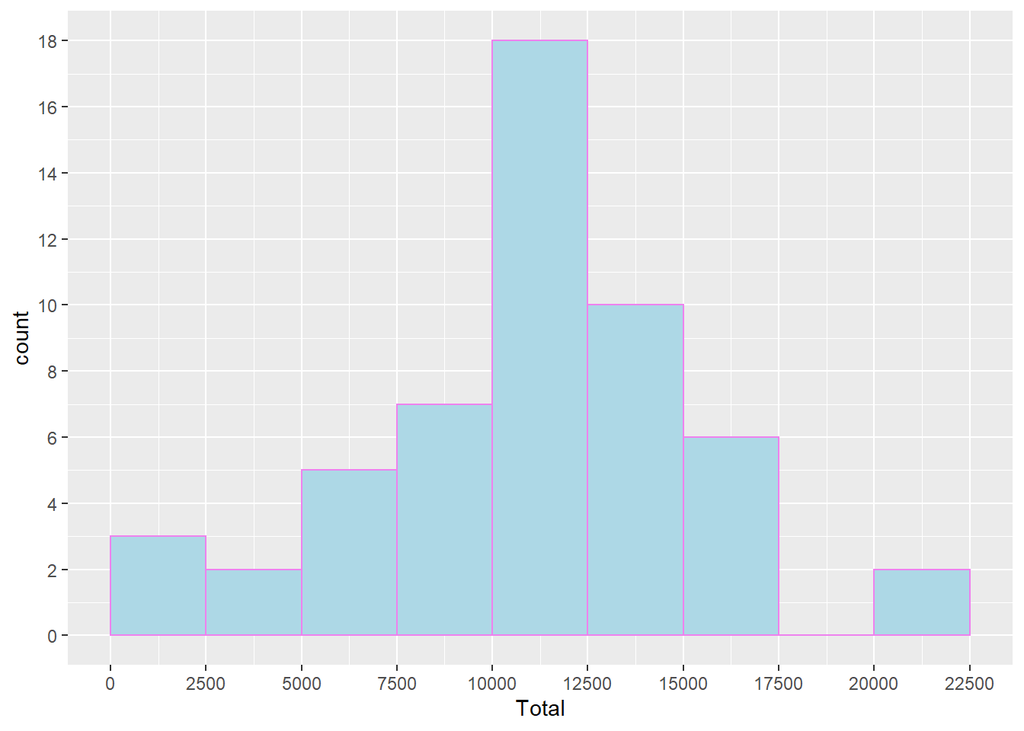

```r
library(ggplot2)

ggplot(data = steps, aes(Total)) + geom_histogram(col = "violet", fill = "lightblue", binwidth = 2500, boundary = 0) + scale_x_continuous(breaks = seq(0,25000,2500)) + scale_y_continuous(breaks = seq(0,18,2))
```

To report the mean and median of the total number steps taken per day, mean() and median() function are put to use:

```r
mean(steps$Total, na.rm = TRUE)
```

```
## [1] 10766.19
```

```r
median(steps$Total, na.rm = TRUE)
```

```
## [1] 10765
```

### Average daily activity pattern

First a dataset is created of 5-minute intervals and the average number of steps taken, averaged across all days

```r
time_int <- aggregate(activity$steps, by = list(activity$interval), mean, na.rm = TRUE)

colnames(time_int) <- c("interval", "average")
```

Then a time series plot is drawn via ggplot2:

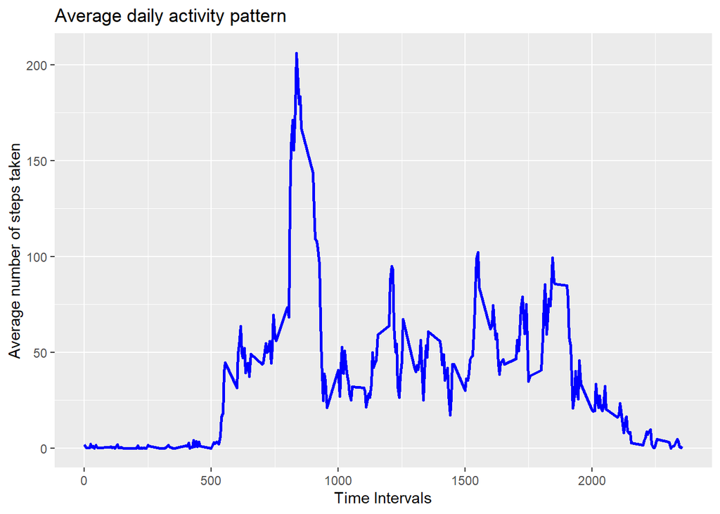

```r
ggplot(data = time_int, aes(interval, average)) + geom_line(col = "blue", size = 1) +ggtitle("Average daily activity pattern") + xlab("Time Intervals") + ylab("Average number of steps taken")
```

For the 5-minute interval containing the maximum number of steps, which.max() function is used

```r
int_max_steps <- time_int[which.max(time_int$average),]$interval

int_max_steps
```

```
## [1] 835
```

### Imputing missing values

Most of the raw data available contains missing values, in the assignment, the number of NA values are determined as

```r
sum(is.na(activity$steps))
```

```
## [1] 2304
```

I have replaced all the missing values with the mean for that 5-minute interval, for that another dataset was created

```r
imp_steps <- time_int$average[match(activity$interval, time_int$interval)]
```

A copy of the original file is made

```r
s <- read.csv("activity.csv")
```

Now to replace the NA values I have used a for loop

```r
for (i in 1:length(s$date))
{
  if(is.na(s$steps[i]))
  {
    s$steps[i] <- imp_steps[i]
  }
}
```

another dataset similar to ‘steps’ is created

```r
s_steps <- aggregate(s$steps, list(s$date), FUN = sum)

colnames(s_steps) <- c("Date","Total")
```

Now for the histogram

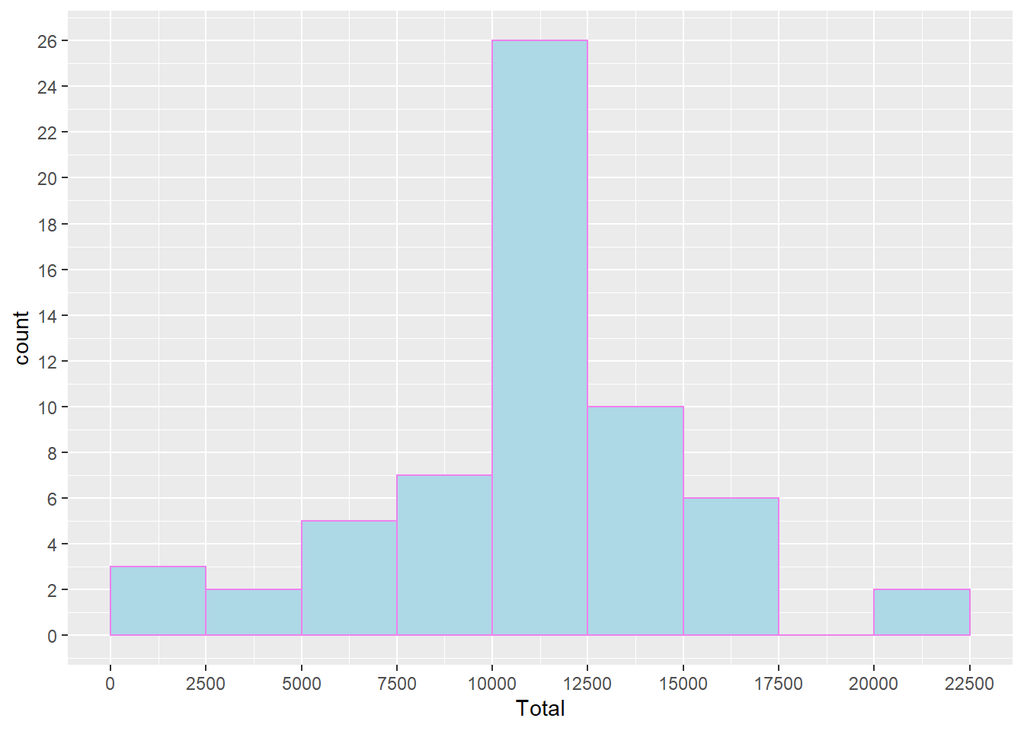

```r
ggplot(data = s_steps, aes(Total)) + geom_histogram(col = "violet", fill = "lightblue", binwidth = 2500, boundary = 0) + scale_x_continuous(breaks = seq(0,25000,2500)) + scale_y_continuous(breaks = seq(0,30,2))
```

To report the mean and median of the total number steps taken per day, mean() and median() functions are put to use:

```r
mean(s_steps$Total)
```

```
## [1] 10766.19
```

```r
median(s_steps$Total)
```

```
## [1] 10766.19
```

### Differences in activity patterns between weekdays and weekends

To accommodate a new factor variable, two additional columns were added for weekday, type of weekday, whether it is a weekend or not sorts.

```r
s$weekday <- weekdays(as.POSIXlt(s$date))

s$day_type <- ifelse(test = s$weekday == c("Saturday","Sunday"), yes = "Weekend", no = "Weekday")
```

After this, another dataset is made comprising of 5-minute intervals and the average number of steps taken, averaged across all weekday days or weekend days

```r
time_int2 <- aggregate(s$steps, by = list(s$interval, s$day_type), mean)

names(time_int2) <- c("interval","Day_type","Average")
```

For the panel plot, I have used qplot() function

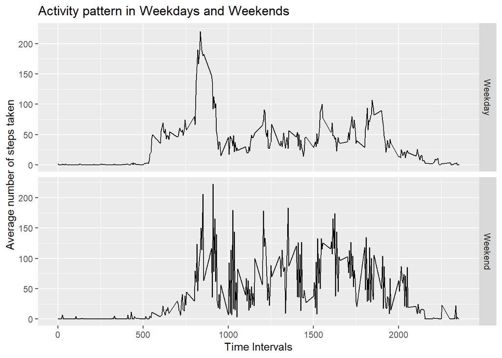

```r
qplot(data = time_int2, x = interval, y = Average, facets = Day_type~., geom="line") + ggtitle("Activity pattern in Weekdays and Weekends") + xlab("Time Intervals") + ylab("Average number of steps taken")
```